# IODS course project

Alvin Khng

# Introduction to Open Data Science - Course Project

# About the project

```
## [1] "Thu Dec 03 19:51:44 2020"
```

## About Me

My name is Alvin Khng and I am current doing my PhD studies in radiochemistry and radiobiology. I am excited for this course as I believed in the power of data statistics. I also feel that this would accelerate the process of data analysis and management i.e. more productivity. I have learnt basic python and used R in courses but most of the time is just follow a template within minimum changes. Therefore, I hope to learn more from this course. Lastly, I chance upon this course through the usual PhD emails regarding modules etc.

## My GitHub Repository

https://github.com/Alvinash/IODS-project

# Regression and model validation

I have finshed the datacamp on regression and model validation.

## Structure of data

```
## 'data.frame':    166 obs. of  7 variables:
##  $ gender  : chr  "F" "M" "F" "M" ...
##  $ age     : int  53 55 49 53 49 38 50 37 37 42 ...
##  $ attitude: num  3.7 3.1 2.5 3.5 3.7 3.8 3.5 2.9 3.8 2.1 ...
##  $ deep    : num  3.58 2.92 3.5 3.5 3.67 ...
##  $ stra    : num  3.38 2.75 3.62 3.12 3.62 ...
##  $ surf    : num  2.58 3.17 2.25 2.25 2.83 ...
##  $ points  : int  25 12 24 10 22 21 21 31 24 26 ...
```

The data contains several variables such as personnel’s gender, age, (global) attitude (towards statistics) their (exam) points, as well as their answers to DEEP, STRAtegic and SURFace question, which follows a Likert scale (1-5).

## ggpair plot of the variables

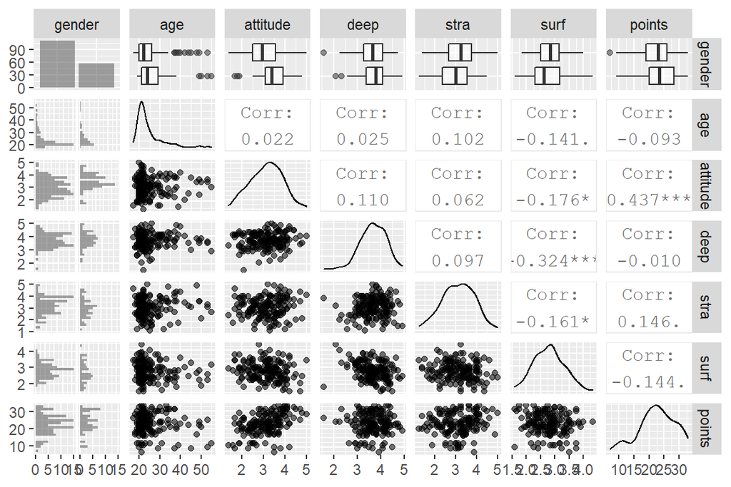

A pair relationship between two variables of all possible combinations. The nature of their plots are dependent on the two variables e.g. scatteplot, box and whiskers, barplot etc.. Their correlation is shown as well.

## Summary of data

```
##     gender               age           attitude          deep
##  Length:166         Min.   :17.00   Min.   :1.400   Min.   :1.583
##  Class :character   1st Qu.:21.00   1st Qu.:2.600   1st Qu.:3.333
##  Mode  :character   Median :22.00   Median :3.200   Median :3.667
##                     Mean   :25.51   Mean   :3.143   Mean   :3.680
##                     3rd Qu.:27.00   3rd Qu.:3.700   3rd Qu.:4.083
##                     Max.   :55.00   Max.   :5.000   Max.   :4.917
##       stra            surf           points
##  Min.   :1.250   Min.   :1.583   Min.   : 7.00
##  1st Qu.:2.625   1st Qu.:2.417   1st Qu.:19.00
##  Median :3.188   Median :2.833   Median :23.00
##  Mean   :3.121   Mean   :2.787   Mean   :22.72
##  3rd Qu.:3.625   3rd Qu.:3.167   3rd Qu.:27.75
##  Max.   :5.000   Max.   :4.333   Max.   :33.00
```

A summary of data showing the type of variables, mean, minimum, maximum and 25%, 50% and 75% quartile values.

Based on the summary of the data, three explanatory variables “attitude”, “surf” and “stra” are picked to fit a regression model against exam points as they have the highest absolute correlation value.

## Linear model fit

```
##
## Call:
## lm(formula = points ~ attitude + stra + surf, data = learning2014)
##
## Residuals:
##      Min       1Q   Median       3Q      Max
## -17.1550  -3.4346   0.5156   3.6401  10.8952
##
## Coefficients:
##             Estimate Std. Error t value Pr(>|t|)
## (Intercept)  11.0171     3.6837   2.991  0.00322 **
## attitude      3.3952     0.5741   5.913 1.93e-08 ***
## stra          0.8531     0.5416   1.575  0.11716
## surf         -0.5861     0.8014  -0.731  0.46563
## ---
## Signif. codes:  0 '***' 0.001 '**' 0.01 '*' 0.05 '.' 0.1 ' ' 1
##
## Residual standard error: 5.296 on 162 degrees of freedom
## Multiple R-squared:  0.2074, Adjusted R-squared:  0.1927
## F-statistic: 14.13 on 3 and 162 DF,  p-value: 3.156e-08
```

The summary shows the statistical test of the fitted model. It can be seen that only “attitude” has a statistical significant relationship with the “point”s variable, concluding that there is a statistical relationship between “attitude” and “exam points”. Therefore, the model is fitted again with just the “attitude” variable.

## Better linear model fit

```
##
## Call:
## lm(formula = points ~ attitude, data = learning2014)
##
## Residuals:
##      Min       1Q   Median       3Q      Max
## -16.9763  -3.2119   0.4339   4.1534  10.6645
##
## Coefficients:
##             Estimate Std. Error t value Pr(>|t|)
## (Intercept)  11.6372     1.8303   6.358 1.95e-09 ***
## attitude      3.5255     0.5674   6.214 4.12e-09 ***
## ---
## Signif. codes:  0 '***' 0.001 '**' 0.01 '*' 0.05 '.' 0.1 ' ' 1
##
## Residual standard error: 5.32 on 164 degrees of freedom
## Multiple R-squared:  0.1906, Adjusted R-squared:  0.1856
## F-statistic: 38.61 on 1 and 164 DF,  p-value: 4.119e-09
```